# R Notebook

**Principles of Data Visualization and Introduction to ggplot2**

I have provided you with data about the 5,000 fastest growing companies in the US, as compiled by Inc. magazine. lets read this in:

```r
inc <- read.csv("https://raw.githubusercontent.com/charleyferrari/CUNY_DATA_608/master/module1/Data/inc5000_data.csv", header= TRUE)
```

And lets preview this data:

```r
head(inc)
```

```
##   Rank                         Name Growth_Rate   Revenue
## 1    1                         Fuhu      421.48 1.179e+08
## 2    2        FederalConference.com      248.31 4.960e+07
## 3    3                The HCI Group      245.45 2.550e+07
## 4    4                      Bridger      233.08 1.900e+09
## 5    5                       DataXu      213.37 8.700e+07
## 6    6 MileStone Community Builders      179.38 4.570e+07
##                       Industry Employees         City State
## 1 Consumer Products & Services       104   El Segundo    CA
## 2          Government Services        51     Dumfries    VA
## 3                       Health       132 Jacksonville    FL
## 4                       Energy        50      Addison    TX
## 5      Advertising & Marketing       220       Boston    MA
## 6                  Real Estate        63       Austin    TX
```

```r
summary(inc)
```

```
##       Rank          Name            Growth_Rate         Revenue
##  Min.   :   1   Length:5001        Min.   :  0.340   Min.   :2.000e+06
##  1st Qu.:1252   Class :character   1st Qu.:  0.770   1st Qu.:5.100e+06
##  Median :2502   Mode  :character   Median :  1.420   Median :1.090e+07
##  Mean   :2502                      Mean   :  4.612   Mean   :4.822e+07
##  3rd Qu.:3751                      3rd Qu.:  3.290   3rd Qu.:2.860e+07
##  Max.   :5000                      Max.   :421.480   Max.   :1.010e+10
##
##    Industry           Employees           City              State
##  Length:5001        Min.   :    1.0   Length:5001        Length:5001
##  Class :character   1st Qu.:   25.0   Class :character   Class :character
##  Mode  :character   Median :   53.0   Mode  :character   Mode  :character
##                     Mean   :  232.7
##                     3rd Qu.:  132.0
##                     Max.   :66803.0
##                     NA's   :12
```

Think a bit on what these summaries mean. Use the space below to add some more relevant non-visual exploratory information you think helps you understand this data:

```r
# Insert your code here, create more chunks as necessary
tail(inc)
```

```
##      Rank               Name Growth_Rate  Revenue                     Industry
## 4996 4996              cSubs        0.34 1.34e+07 Business Products & Services
## 4997 4997          Dot Foods        0.34 4.50e+09              Food & Beverage
## 4998 4998 Lethal Performance        0.34 6.80e+06                       Retail
## 4999 4999   ArcaTech Systems        0.34 3.26e+07           Financial Services
## 5000 5000                INE        0.34 6.80e+06                  IT Services
## 5001 5000               ALL4        0.34 4.70e+06       Environmental Services
##      Employees         City State
## 4996        19     Montvale    NJ
## 4997      3919 Mt. Sterling    IL
## 4998         8   Wellington    FL
## 4999        63       Mebane    NC
## 5000        35     Bellevue    WA
## 5001        34    Kimberton    PA
```

```r
# dimensions
dim(inc)
```

```
## [1] 5001    8
```

```r
# column names
colnames(inc)
```

```
## [1] "Rank"        "Name"        "Growth_Rate" "Revenue"     "Industry"
## [6] "Employees"   "City"        "State"
```

```r
# total nas
sum(is.na(inc))
```

```
## [1] 12
```

## Question 1

Create a graph that shows the distribution of companies in the dataset by State (ie how many are in each state). There are a lot of States, so consider which axis you should use. This visualization is ultimately going to be consumed on a ‘portrait’ oriented screen (ie taller than wide), which should further guide your layout choices.

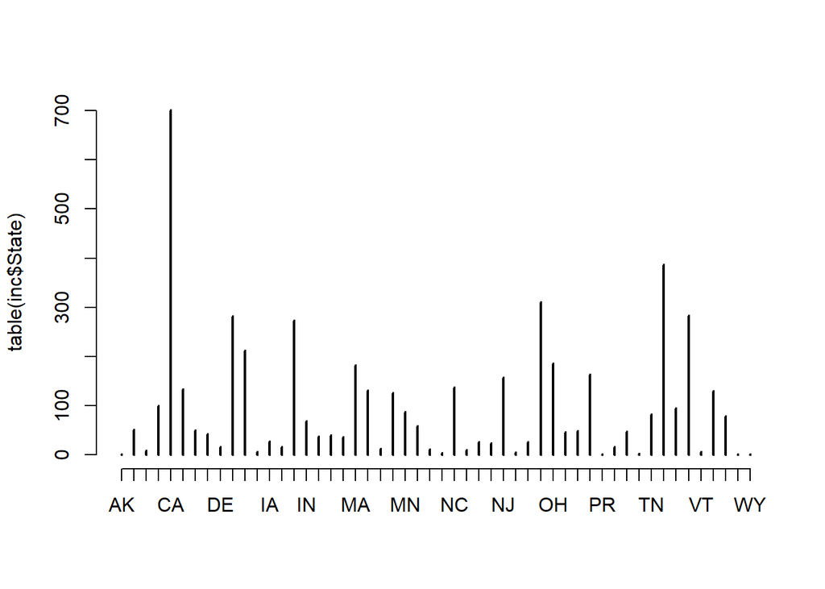

```r
# Answer Question 1 here

plot(table(inc$State))
```

## Question 2

Lets dig in on the state with the 3rd most companies in the data set. Imagine you work for the state and are interested in how many people are employed by companies in different industries. Create a plot that shows the average and/or median employment by industry for companies in this state (only use cases with full data, use R’s `complete.cases()` function.) In addition to this, your graph should show how variable the ranges are, and you should deal with outliers.

```r
# Answer Question 2 here

# Sort and Filter top 3
state_max = as.matrix(table(inc$State))

third_largest_state = state_max[order(state_max[,1],decreasing=TRUE),][3]
print(third_largest_state)
```

```
##  NY
## 311
```

```r
filt_crit = "NY"

third_largest_filt_data = subset(inc,State == filt_crit)
third_largest_filt_data = third_largest_filt_data[complete.cases(third_largest_filt_data),]
head(third_largest_filt_data)
```

```
##    Rank                      Name Growth_Rate  Revenue
## 26   26              BeenVerified       84.43 13700000
## 30   30                  Sailthru       73.22  8100000
## 37   37              YellowHammer       67.40 18000000
## 38   38                 Conductor       67.02  7100000
## 48   48 Cinium Financial Services       53.65  5900000
## 70   70                  33Across       44.99 27900000
##                        Industry Employees      City State
## 26 Consumer Products & Services        17  New York    NY
## 30      Advertising & Marketing        79  New York    NY
## 37      Advertising & Marketing        27  New York    NY
## 38      Advertising & Marketing        89  New York    NY
## 48           Financial Services        32 Rock Hill    NY
## 70      Advertising & Marketing        75  New York    NY
```

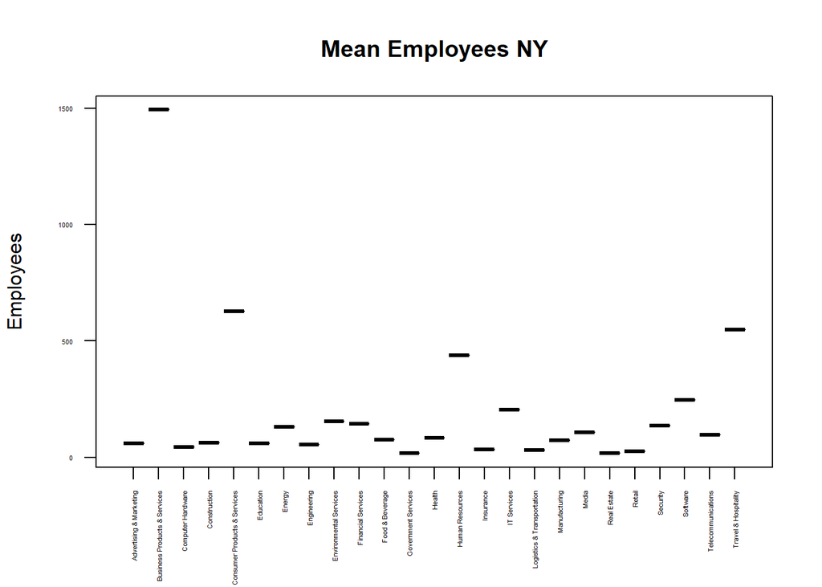

```r
## initial Plots

mean_third_data = aggregate(third_largest_filt_data$Employees,list(third_largest_filt_data$Industry),FUN=mean)

median_third_data = aggregate(third_largest_filt_data$Employees,list(third_largest_filt_data$Industry),FUN=median)

mean_third_data$Group.1 = as.factor(mean_third_data$Group.1)
median_third_data$Group.1 = as.factor(median_third_data$Group.1)

par(cex.lab=1,cex.axis=.35)
plot(mean_third_data$Group.1,mean_third_data$x,las=2,ylab='Employees',main = 'Mean Employees NY',xlab="")
```

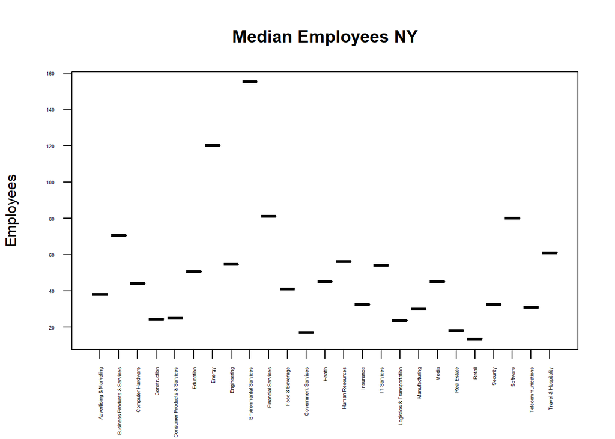

```r
plot(median_third_data$Group.1,median_third_data$x,las=2,ylab='Employees',main = 'Median Employees NY',xlab="")
```

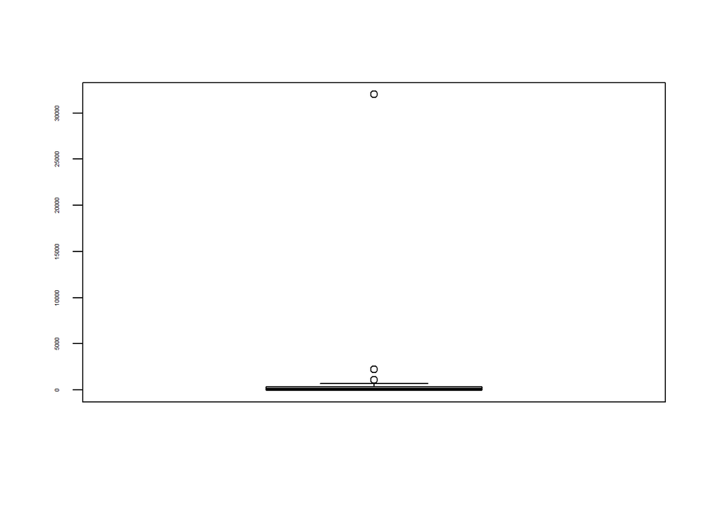

```r
## check outlier
boxplot(third_largest_filt_data[third_largest_filt_data$Industry=='Business Products & Services',]$Employees)
```

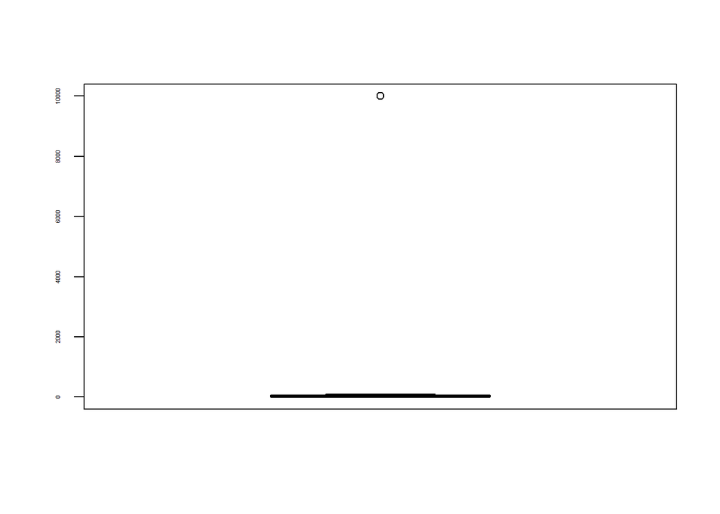

```r
boxplot(third_largest_filt_data[third_largest_filt_data$Industry=='Consumer Products & Services',]$Employees)
```

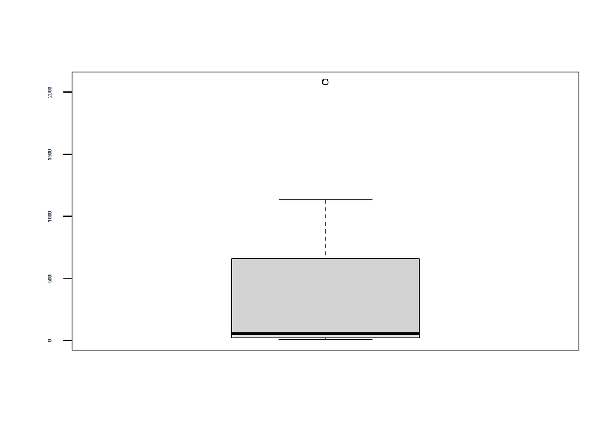

```r
boxplot(third_largest_filt_data[third_largest_filt_data$Industry=='Human Resources',]$Employees)
```

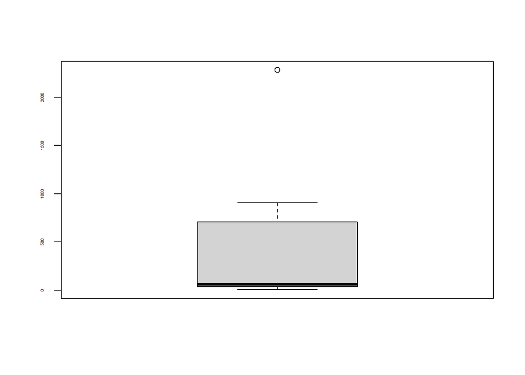

```r
boxplot(third_largest_filt_data[third_largest_filt_data$Industry=='Travel & Hospitality',]$Employees)
```

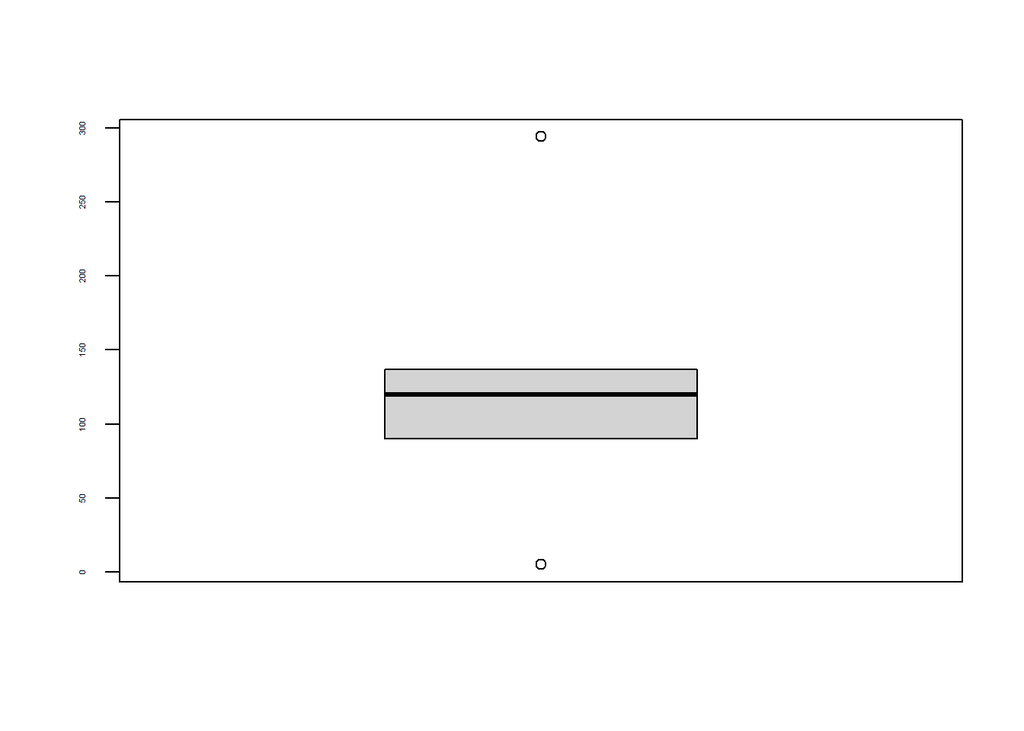

```r
boxplot(third_largest_filt_data[third_largest_filt_data$Industry=='Energy',]$Employees)
```

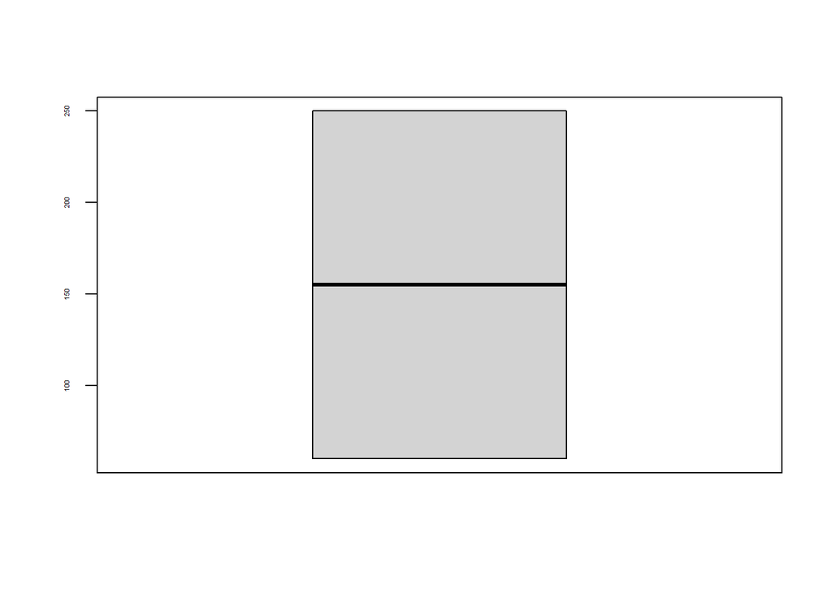

```r
boxplot(third_largest_filt_data[third_largest_filt_data$Industry=='Environmental Services',]$Employees)
```

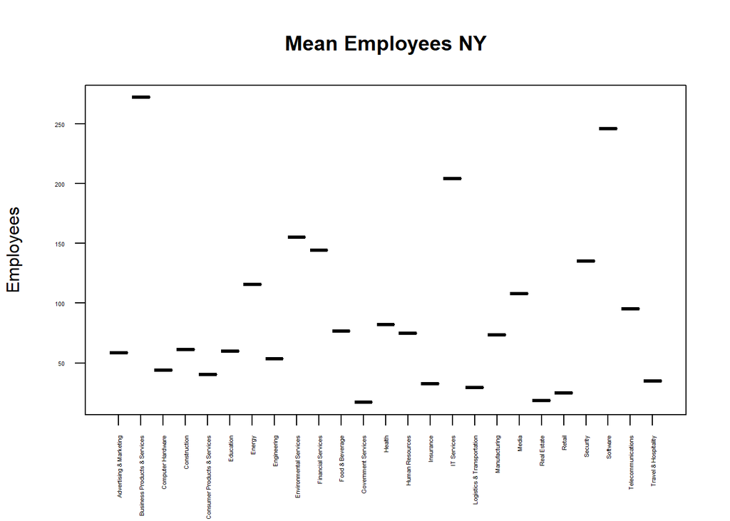

```r
## Remove Outlier

new_filt_table = subset(third_largest_filt_data,Rank!=4577 & Rank!=4936 & Rank!=1499 & Rank!=2995 & Rank!=3136 & Rank!=3899 & Rank!=4003 & Rank!=4747 & Rank!=2556 & Rank!=2675)


newmean_third_data = aggregate(new_filt_table$Employees,list(new_filt_table$Industry),FUN=mean)

newmedian_third_data = aggregate(new_filt_table$Employees,list(new_filt_table$Industry),FUN=median)

newmean_third_data$Group.1 = as.factor(newmean_third_data$Group.1)
newmedian_third_data$Group.1 = as.factor(newmedian_third_data$Group.1)

par(cex.lab=1,cex.axis=.35)
plot(newmean_third_data$Group.1,newmean_third_data$x,las=2,ylab='Employees',main = 'Mean Employees NY',xlab="")
```

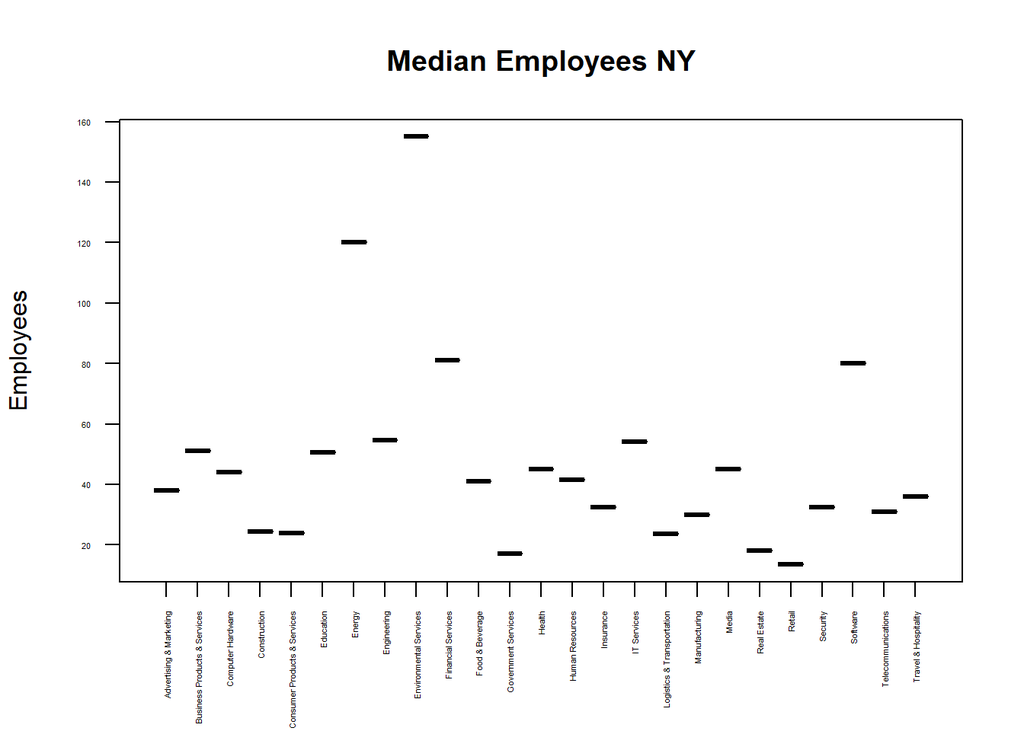

```r
plot(newmedian_third_data$Group.1,newmedian_third_data$x,las=2,ylab='Employees',main = 'Median Employees NY',xlab="")
```

## Question 3

Now imagine you work for an investor and want to see which industries generate the most revenue per employee. Create a chart that makes this information clear. Once again, the distribution per industry should be shown.

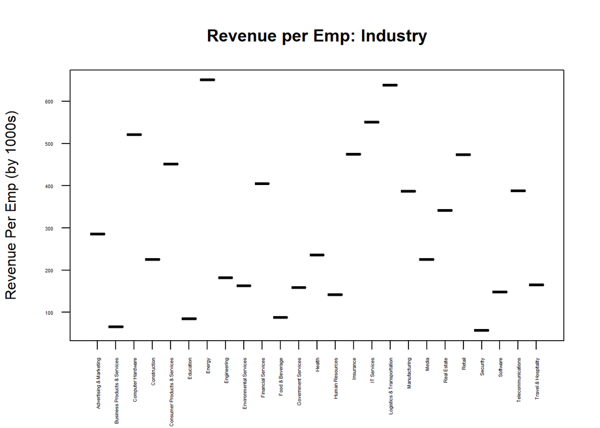

```r
# Answer Question 3 here


agg_data_rev_emp = aggregate(list(emp=third_largest_filt_data$Employees,rev=third_largest_filt_data$Revenue),list(industry=third_largest_filt_data$Industry),FUN=sum)

agg_data_rev_emp$rev_per_emp = agg_data_rev_emp$rev/agg_data_rev_emp$emp
#divide by 1000 for scaling
agg_data_rev_emp$rev_per_emp = agg_data_rev_emp$rev_per_emp/1000

agg_data_rev_emp$industry = as.factor(agg_data_rev_emp$industry)


par(cex.lab=1,cex.axis=.35)
plot(agg_data_rev_emp$industry,agg_data_rev_emp$rev_per_emp,las=2,ylab='Revenue Per Emp (by 1000s)',main = 'Revenue per Emp: Industry',xlab="")
```